# Lunar and diel activity analysis

This vignette demonstrates the Bayesian analysis and ternary classification used in “The moon’s influence on the activity of tropical forest mammals” (Bischof *et al.* 2024, DOI: 10.1098/rspb.2024.0683). The code in the vignette was created and run in R version 4.3.0 (R Core Team 2023).

### Load Libraries

We load the libraries needed to run the example (libraries may need to be installed first).

```r
library(nimble) # use version 1.0.0 (issues with dmultinom function in newer versions as of May 2024)
library(ggplot2)
library(R.utils)
library(reshape2)
library(dplyr)
library(Ternary)
library(coda)
```

### Source additional functions

We load additional custom functions for processing MCMC output and making ternary diagrams.

```r
source("functions.R")
```

# Analysis 1: Diel and lunar activity

### Define model

We use package `nimble` (de Valpine et al. 2017; NIMBLE Development Team 2020) for Bayesian model fitting. Here, we define the `nimble` model for analysis 1, which we use to determine the prevalence of apparent lunar philia and lunar phobia among tropical forest mammals detected using camera traps (avoidance or attraction to certain lunar phases during nocturnal activity). The model has two submodels, one to estimate multinomial probabilities associated with diel activity (day, twilight, night) and one to estimate multinomial probabilities associated with only nocturnal activity (“lunar activity”: full moon, new moon, transitional). Estimation is performed independently for each species.

```r
modelCode1 <- nimbleCode({
  for (i in 1:n.species) {
    for (k in 1:(K - 1)) {
      beta.diel0[i, k] ~ dunif(-20, 20)

    }#k
  }#i

  for (i in 1:n.species) {
    for (l in 1:(L - 1)) {
      beta.lunar0[i, l] ~ dunif(-20, 20)

    }#l
  }#i

  for (i in 1:n.species) {
    #----DESIGNATION OF ACTIVITY TO DIEL PHASES

    for (k in 1:(K - 1)) {
      etadot.diel[i, k]  <- beta.diel0[i, k]

      exp.eta.diel[i, k] <-
        exp(etadot.diel[i, k] + offset.diel[i, k])
    }#k
    etadot.diel[i, K] <- 0
    exp.eta.diel[i, K] <- 1

    Z.diel[i] <- sum(exp.eta.diel[i, 1:K])
    p.diel[i, 1:K] <- exp.eta.diel[i, 1:K] / Z.diel[i]
    y.diel[i, 1:K] ~ dmulti(p.diel[i, 1:K], N.diel[i])

    #----DESIGNATION OF ACTIVITY TO LUNAR PHASES/PERIODS

    for (l in 1:(L - 1)) {
      etadot.lunar[i, l]  <-  beta.lunar0[i, l]
      exp.eta.lunar[i, l] <-
        exp(etadot.lunar[i, l] + offset.lunar[i, l])
    }#l

    etadot.lunar[i, L] <- 0
    exp.eta.lunar[i, L] <- 1

    Z.lunar[i] <- sum(exp.eta.lunar[i, 1:L])
    p.lunar[i, 1:L] <- exp.eta.lunar[i, 1:L] / Z.lunar[i]
    y.lunar[i, 1:L] ~ dmulti(p.lunar[i, 1:L], N.lunar[i])

  }#i

  #----DERIVED VARIABLES

  for (i in 1:n.species) {
    Zdot.diel[i] <- sum(exp(etadot.diel[i, 1:K]))
    pdot.diel[i, 1:K] <- exp(etadot.diel[i, 1:K]) / Zdot.diel[i]

    Zdot.lunar[i] <- sum(exp(etadot.lunar[i, 1:L]))
    pdot.lunar[i, 1:L] <-
      exp(etadot.lunar[i, 1:L]) / Zdot.lunar[i]

  }#i

})
```

### Load input data

We load the file containing the various objects serving as input for the NIMBLE model.

```r
load("InputData1.RData")
```

### Fit the model

Here we fit the nimble model. We chose a low number of iterations in this example, for faster fitting.

```r
nimOutput1 <- nimbleMCMC(
    code = modelCode1,
    constants = nimConstants1,
    data = nimData1,
    inits = nimInits1,
    monitors = c("pdot.diel","pdot.lunar"),
    niter = 10000,
    nburnin = 3000,
    thin = 8,
    nchains = 3,
    samplesAsCodaMCMC = TRUE
  )
```

```
|-------------|-------------|-------------|-------------|
|-------------------------------------------------------|
|-------------|-------------|-------------|-------------|
|-------------------------------------------------------|
|-------------|-------------|-------------|-------------|
|-------------------------------------------------------|
```

### Process MCMC output

We process the output from `nimbleMCMC` for easier handling of the posterior samples.

```r
NimbleOutputCoda1<- ProcessCodaOutput(nimOutput1, DIC = FALSE)
```

```
Calculating statistics.......

Done.
```

`ProcessCodaOutput` also provides several statistics for the estimated parameters, as well as different metrics for evaluating the efficiency and convergence of the chains, such as *Rhat* values. *Rhat* values < 1.1 indicate that convergence has been achieved (Gelman 1996).

```r
summary(as.numeric(NimbleOutputCoda1$Rhat$pdot.lunar))
```

```
   Min. 1st Qu.  Median    Mean 3rd Qu.    Max.
 0.9995  1.0001  1.0005  1.0009  1.0014  1.0221
```

### Review traceplots

Generate and inspect traceplots to visually assess convergence and mixing of the MCMC chains.

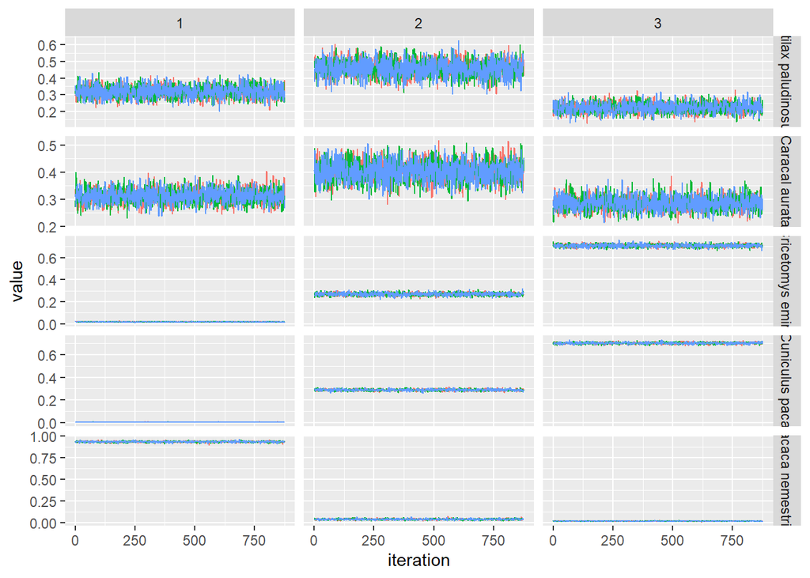

```r
parms<-c("pdot.diel","pdot.lunar")
n.chains<-3

x<-parms[1]
posterior.df<-lapply(parms,function(x){
  ins<-NimbleOutputCoda1$sims.list[[x]]
  dimnames(ins)<-list(NULL,species.info1$SpeciesName,NULL)
  out<-melt(ins)
  colnames(out)<-c("iteration",paste("dim",1:(length(dim(ins))-1),sep=""),"value")
  out$chain<-rep(1:n.chains,each=dim(ins)[1]/n.chains)
  out$iteration<-rep(1:(dim(ins)[1]/n.chains),n.chains)

  return(out)
})

names(posterior.df)<-parms


sp<-sample(species.info1$SpeciesName,5)

x<-posterior.df$pdot.lunar
traceplot.ls<-lapply(posterior.df,function(x){
  ggplot(x[x$dim1%in%sp,]) +
    geom_line(aes(x=iteration,y=value,color=factor(chain))) +
    facet_grid(dim1~dim2,scales = "free")+
    theme(legend.position = "none")

})
names(traceplot.ls)<-parms
traceplot.ls$pdot.diel
```

### Plot ternary diagrams

To create the ternary diagrams, we first extract and prepare the posteriors of the diel and lunar multinomial probabilities.

```r
#-----BASE POSTERIOR (DIEL)
type.list.diel<-c("day","twilight","night")
type.list.diel2<-c("diurnal","crepuscular","nocturnal")

postd.diel<-NimbleOutputCoda1$sims.list$pdot.diel
dimnames(postd.diel)<-list(NULL, species.info1$SpeciesName,type.list.diel)

#-----BASE POSTERIOD (LUNAR)

type.list.lunar<-c("fullmoon","newmoon","transitional")
type.list.lunar2<-c("lunarphilic","lunarphobic","intermediate")

postd.lunar<-NimbleOutputCoda1$sims.list$pdot.lunar
dimnames(postd.lunar)<-list(NULL, species.info1$SpeciesName,type.list.lunar)
```

We plot the ternary diagram to visualize the diel activity of, for example, the white-lipped peccary. We use wrapper function based on package `Ternary` (Smith 2017) to show delineations of custom ternary regions.

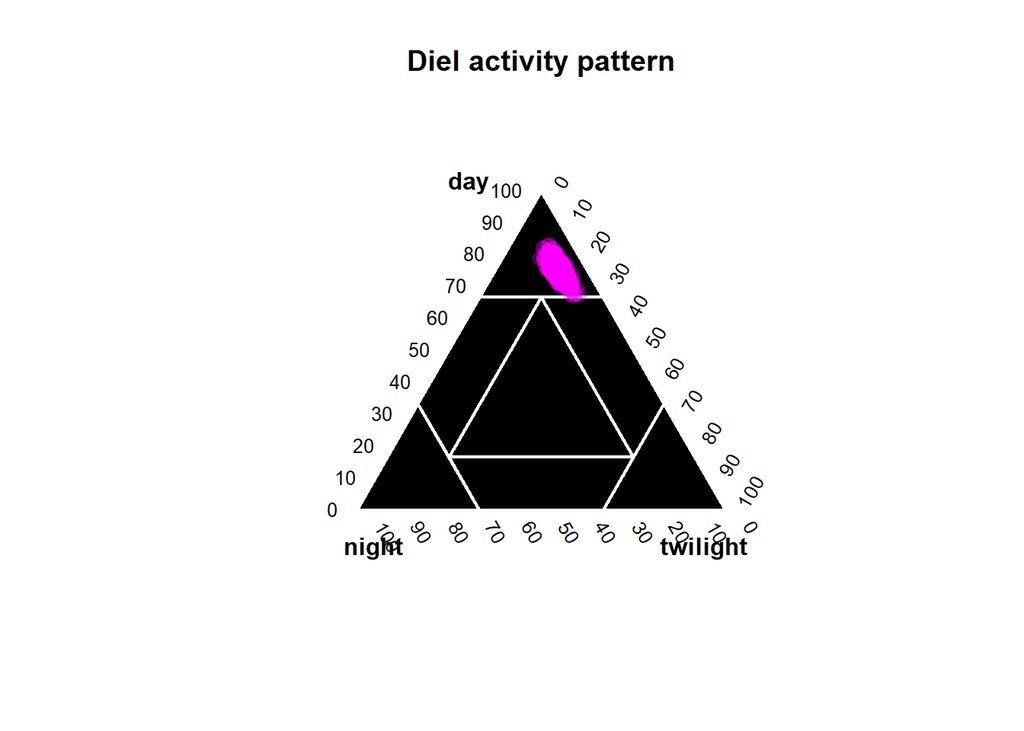

```r
sp <- "Tayassu pecari"

# Initialize the plot
TernaryPlot(
  atip = type.list.diel[1],
  btip = type.list.diel[2],
  ctip = type.list.diel[3],
  grid.col = NA,
  grid.minor.col = NA,
  main = "Diel activity pattern"
)

plotTernaryRegions(
  n.categories = 7,
  col = "black",
  lwd = 2,
  border = "white"
)

idx <- which(species.info1$SpeciesName == sp)

n <- 1000 #--subsample of the posterior sample for faster plotting

coordinates <-
  postd.diel[sample(dim(postd.diel)[1], min(n, dim(postd.diel)[1])), idx, type.list.diel]

TernaryPoints(
  coordinates,
  col = adjustcolor("magenta", 0.2),
  pch = 19,
  cex = 1.3
)
```

We do the same for peccary’s lunar activity:

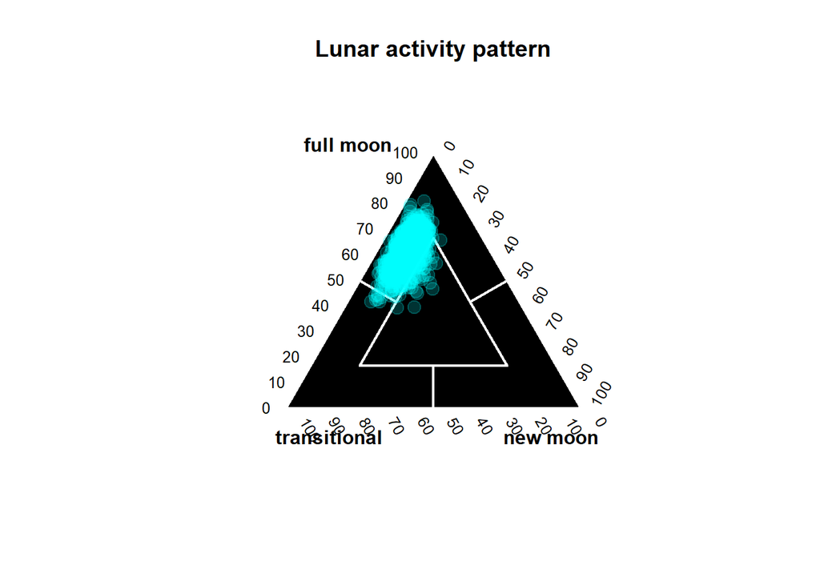

```r
# Initialize the plot

TernaryPlot(
  atip = "full moon",
  btip = "new moon",
  ctip = "transitional",
  grid.col = NA,
  grid.minor.col = NA,
  main = "Lunar activity pattern"
)

plotTernaryRegions(
  n.categories = "4B",
  col = "black",
  lwd = 2,
  border = "white"
)

coordinates <-
  postd.lunar[sample(dim(postd.lunar)[1], min(n, dim(postd.lunar)[1])), idx, type.list.lunar]

TernaryPoints(coordinates,
              col = adjustcolor("cyan", 0.2),
              pch = 19,
              cex = 1.5)
```

### Determine activity categories

We can designate the posterior samples of multinomial probabilities according to the ternary categorization we chose for diel behavior (7 categories; see Figure 2 in the article). Diel activity category is determined based on the position of each posterior sample in the ternary diagram; overall diel activity for the species is the most common diel category in the posterior sample.

```r
fit<-species.info1%>%select(SpeciesName,realm)

#---DIEL
postd<-NimbleOutputCoda1$sims.list$pdot.diel
dimnames(postd)[[2]]<-fit$SpeciesName
dimnames(postd)[[3]]<-type.list.diel
postd.df<-postd %>% melt() %>% tibble()
names(postd.df)<-c("iteration","SpeciesName","period","pdot")
postd.df<-dcast(postd.df,iteration + SpeciesName ~ period, value.var = "pdot",drop = FALSE)
postd.df$category<-apply(postd.df[,type.list.diel],1,function(x)findTernaryRegion(x,x.names=type.list.diel2))

fit.diel<-postd.df %>% group_by(SpeciesName) %>%
  summarize(day=mean(day),twilight=mean(twilight),night =mean(night),
            category= most.common(category,keep.equals=TRUE) )

print(fit.diel)
```

```
# A tibble: 86 × 5
   SpeciesName                day twilight  night category
   <fct>                    <dbl>    <dbl>  <dbl> <chr>
 1 Atherurus africanus    0.0314     0.298 0.671  nocturnal
 2 Atherurus macrourus    0.0118     0.277 0.711  nocturnal
 3 Atilax paludinosus     0.317      0.461 0.222  cathemeral
 4 Bdeogale crassicauda   0.00160    0.410 0.589  crepuscular_nocturnal
 5 Bdeogale nigripes      0.0515     0.190 0.759  nocturnal
 6 Canis adustus          0.155      0.590 0.254  crepuscular_nocturnal
 7 Caracal aurata         0.312      0.403 0.285  cathemeral
 8 Cephalophus callipygus 0.645      0.287 0.0680 diurnal_crepuscular
 9 Cephalophus dorsalis   0.0625     0.375 0.563  crepuscular_nocturnal
10 Cephalophus harveyi    0.610      0.297 0.0930 diurnal_crepuscular
# ℹ 76 more rows
```

Similarly, we designate the posterior samples of multinomial probabilities according to the ternary categorization we chose for lunar behavior (4, categories; see Figure 2 in the article):

```r
postd.lunar<-NimbleOutputCoda1$sims.list$pdot.lunar
dimnames(postd.lunar)[[2]]<-fit$SpeciesName
dimnames(postd.lunar)[[3]]<-type.list.lunar
postd.lunar.df<-postd.lunar %>% melt() %>% tibble()
names(postd.lunar.df)<-c("iteration","SpeciesName","period","pdot")
postd.lunar.df<-dcast(postd.lunar.df,iteration + SpeciesName ~ period, value.var = "pdot",drop = FALSE)
postd.lunar.df$category<-apply(postd.lunar.df[,type.list.lunar],1,function(x)findTernaryRegion(x,x.names=type.list.lunar2,n.regions = "4B",name.center = "indifferent"))

fit.lunar<-postd.lunar.df %>% group_by(SpeciesName) %>%
  summarize(fullmoon=mean(fullmoon),newmoon=mean(newmoon),transitional =mean(transitional),
            category= most.common(category,keep.equals=TRUE))

print(fit.lunar)
```

```
# A tibble: 86 × 5
   SpeciesName            fullmoon newmoon transitional category
   <fct>                     <dbl>   <dbl>        <dbl> <chr>
 1 Atherurus africanus       0.105   0.567        0.328 lunarphobic
 2 Atherurus macrourus       0.197   0.509        0.295 indifferent
 3 Atilax paludinosus        0.265   0.364        0.370 indifferent
 4 Bdeogale crassicauda      0.320   0.328        0.352 indifferent
 5 Bdeogale nigripes         0.283   0.413        0.304 indifferent
 6 Canis adustus             0.516   0.207        0.277 indifferent
 7 Caracal aurata            0.305   0.397        0.298 indifferent
 8 Cephalophus callipygus    0.368   0.314        0.319 indifferent
 9 Cephalophus dorsalis      0.361   0.310        0.329 indifferent
10 Cephalophus harveyi       0.365   0.295        0.340 indifferent
# ℹ 76 more rows
```

# Analysis 2: Relationship with nocturnality

### Define model

Here, we define the `nimble` model for analysis 2, which we use to test the hypothesis that lunar phobia is positively linked with nocturnality in tropical forest mammals. This model has two submodels, one to estimate multinomial probabilities associated with diel activity and one to estimate multinomial probabilities associated with lunar activity. The species-specific probability of being active at night (estimated in the diel activity submodel, normalized and calibrate for availability and effort) is used as a covariate on the multinomial probabilities in the lunar activity submodel.

```r
modelCode2 <- nimbleCode({
  for (i in 1:n.species) {
    for (k in 1:(K - 1)) {
      beta.diel0[i, k] ~ dunif(-20, 20)


    }#k

  }#i

  for (l in 1:(L - 1)) {
    beta.lunar0[l] ~ dunif(-20, 20)
    beta.lunar.nocturnal[l] ~ dunif(-10, 10)

    sigma[l] ~ dinvgamma(2, 1)

    for (i in 1:n.species) {
    beta0.with.epsilon[i, l] ~  dnorm(beta.lunar0[l], var = sigma[l])
      }#i

  }#l

  for (i in 1:n.species) {
    #----DESIGNATION OF ACTIVITY TO DIEL PHASES

    for (k in 1:(K - 1)) {
      etadot.diel[i, k]  <- beta.diel0[i, k]

      exp.eta.diel[i, k] <- exp(etadot.diel[i, k] + offset.diel[i, k])
    }#k
    etadot.diel[i, K] <- 0
    exp.eta.diel[i, K] <- 1

    Z.diel[i] <- sum(exp.eta.diel[i, 1:K])
    p.diel[i, 1:K] <- exp.eta.diel[i, 1:K] / Z.diel[i]
    y.diel[i, 1:K] ~ dmulti(p.diel[i, 1:K], N.diel[i])

    #----DESIGNATION OF ACTIVITY TO LUNAR PHASES/PERIODS

    for (l in 1:(L - 1)) {

      etadot.lunar[i, l]  <- beta0.with.epsilon[i, l] +  beta.lunar.nocturnal[l] * pdot.diel[i, 3]
      exp.eta.lunar[i, l] <-  exp(etadot.lunar[i, l] + offset.lunar[i, l])
    }#l

    etadot.lunar[i, L] <- 0
    exp.eta.lunar[i, L] <- 1

    Z.lunar[i] <- sum(exp.eta.lunar[i, 1:L])
    p.lunar[i, 1:L] <- exp.eta.lunar[i, 1:L] / Z.lunar[i]
    y.lunar[i, 1:L] ~ dmulti(p.lunar[i, 1:L], N.lunar[i])

  }#i

  #----DERIVED VARIABLES

  for (i in 1:n.species) {
    Zdot.diel[i] <- sum(exp(etadot.diel[i, 1:K]))
    pdot.diel[i, 1:K] <- exp(etadot.diel[i, 1:K]) / Zdot.diel[i]

    Zdot.lunar[i] <- sum(exp(etadot.lunar[i, 1:L]))
    pdot.lunar[i, 1:L] <-      exp(etadot.lunar[i, 1:L]) / Zdot.lunar[i]

  }#i

})
```

### Load input data

We load the file containing the various objects serving as input for the model.

```r
load("InputData2.RData")
```

### Fit the model

We fit the nimble model.

```r
  nimOutput2 <- nimbleMCMC(
    code = modelCode2,
    constants = nimConstants2,
    data = nimData2,
    inits = nimInits2,
    monitors = c("beta.diel0","beta.lunar0","pdot.diel","pdot.lunar","beta.lunar.nocturnal","sigma"),
    niter = 10000,
    nburnin = 3000,
    thin = 8,
    nchains = 3,
    samplesAsCodaMCMC = TRUE
  )
```

```
|-------------|-------------|-------------|-------------|
|-------------------------------------------------------|
|-------------|-------------|-------------|-------------|
|-------------------------------------------------------|
|-------------|-------------|-------------|-------------|
|-------------------------------------------------------|
```

### Process MCMC output

We process the MCMC output and check for convergence.

```r
NimbleOutputCoda2<-ProcessCodaOutput(nimOutput2, DIC = FALSE)
```

```
Calculating statistics.......

Done.
```

```r
summary(as.numeric(NimbleOutputCoda2$Rhat$beta.lunar.nocturnal))
```

```
   Min. 1st Qu.  Median    Mean 3rd Qu.    Max.
  1.006   1.020   1.035   1.035   1.049   1.063
```

### Plot results

First, we prepare the MCMC output for plotting.

```r
mean.lines<-data.frame(
  fullmoon=NimbleOutputCoda2$mean$beta.lunar0[1] + NimbleOutputCoda2$mean$beta.lunar.nocturnal[1] * seq(0,1,length.out=100),
  pdot.diel=seq(0,1,length.out=100)
)

sample.lines<-expand.grid( pdot.diel=seq(0,1,length.out=100),idx=sample(dim(NimbleOutputCoda2$sims.list$beta.lunar.nocturnal)[1],500 ))%>%
  mutate(beta.lunar01=NimbleOutputCoda2$sims.list$beta.lunar0[idx,1],
         beta.lunar.nocturnal1=NimbleOutputCoda2$sims.list$beta.lunar.nocturnal[idx,1])%>%
  mutate(fullmoon=beta.lunar01+beta.lunar.nocturnal1*pdot.diel)
```

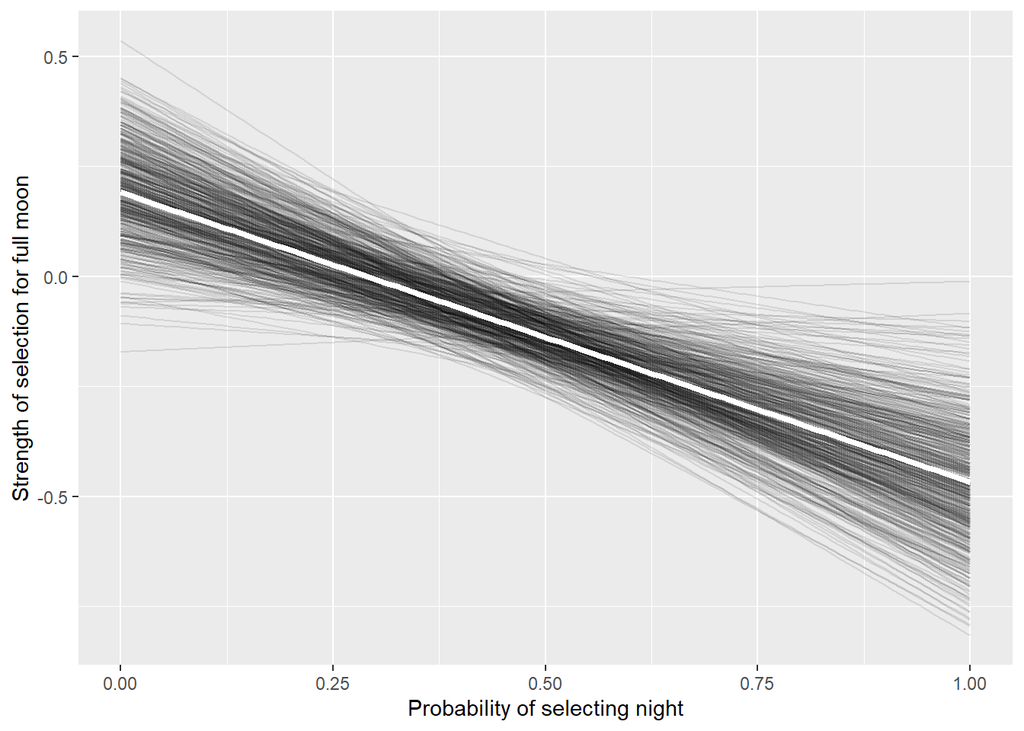

```r
ggplot() +
  geom_path(data=sample.lines,mapping=aes(y=fullmoon,x=pdot.diel,group = idx),alpha=0.1)+
  geom_path(data=mean.lines,mapping=aes(y=fullmoon,x=pdot.diel),alpha=1,linewidth=1.5,color="white") +
xlab("Probability of selecting night")+
ylab("Strength of selection for full moon")
```

Note that the Y axis shows the non-normalized strength of selection for full moon on the scale of the linear predictor. Each semi-transparent line represents predictions associated with one posterior sample (shown are 500 random samples out of all iterations); the white line corresponds to the prediction based on mean parameter estimates (slope and effect).

# Analysis 3: Activity shifting

### Define model

Here, we define the `nimble` model for analysis 3, which we use to detect and quantify changes in diel activity patterns and total activity levels during periods (multiple days) with full moon. This model has two submodels, one with the total number of activity events formulated as the outcome of a Poisson process and one for multinomial probabilities associated with diel activity. Both submodels include terms that contrast periods with and without at least 15 minutes of full moon at night. Estimation is performed independently for each species.

```r
modelCode3 <- nimbleCode({
  for (m in 1:2) {
    #  lunar periods
    for (i in 1:n.species) {
      for (k in 1:(K - 1)) {
        beta2dot.diel0[i, k, m] ~ dunif(-20, 20)

      }#k

    }#i
  }#m


  for (i in 1:n.species) {
    for (m in 1:2) {
      #  lunar periods
      beta2dot0[i, m] ~ dunif(-10, 10)
    }#m
  }#i

  for (m in 1:2) {
    #  lunar periods
    for (i in 1:n.species) {
      #----DESIGNATION OF ACTIVITY TO DIEL PHASES

      for (k in 1:(K - 1)) {
        etadot.diel[i, k, m]  <- beta2dot.diel0[i, k, m]

        exp.eta.diel[i, k, m] <-
          exp(etadot.diel[i, k, m] + offset2dot.diel[i, k, m])
      }#k
      etadot.diel[i, K, m] <- 0
      exp.eta.diel[i, K, m] <- 1

      Z.diel[i, m] <- sum(exp.eta.diel[i, 1:K, m])
      p2dot.diel[i, 1:K, m] <- exp.eta.diel[i, 1:K, m] / Z.diel[i, m]
      y2dot.diel[i, 1:K, m] ~ dmulti(p2dot.diel[i, 1:K, m], N2dot.diel[i, m])

      #----TOTAL ACTIVITY

      eta.N.dot[i, m] <-  beta2dot0[i, m]

      lambda[i, m] <- exp(eta.N.dot[i, m] + offset2dot[i, m])

      N2dot.diel[i, m] ~ dpois(lambda[i, m])



    }#i
  }#m
  #----DERIVED VARIABLES

  for (m in 1:2) {
    #  lunar periods
    for (i in 1:n.species) {
      Zdot.diel[i, m] <- sum(exp(etadot.diel[i, 1:K, m]))
      phat.diel[i, 1:K, m] <-
        exp(etadot.diel[i, 1:K, m]) / Zdot.diel[i, m]

      lambda.dot[i, m]  <-
        exp(eta.N.dot[i, m])#--value of lambda with the offset corrected

    }#i
  }#m


})
```

### Load input data

We load the file with the objects that serve as input to the Bayesian model.

```r
load("InputData3.RData")
```

### Fit the model

We fit the model.

```r
  nimOutput3 <- nimbleMCMC(
    code = modelCode3, #--SAME AS THE FIRST ANALYSIS
    constants = nimConstants3,
    data = nimData3,
    inits = nimInits3,
    monitors = c("lambda.dot","phat.diel"),
    niter = 10000,
    nburnin = 3000,
    thin = 8,
    nchains = 3,
    samplesAsCodaMCMC = TRUE
)
```

```
|-------------|-------------|-------------|-------------|
|-------------------------------------------------------|
|-------------|-------------|-------------|-------------|
|-------------------------------------------------------|
|-------------|-------------|-------------|-------------|
|-------------------------------------------------------|
```

### Process MCMC output

We process the MCMC output and check for convergence.

```r
NimbleOutputCoda3 <-  ProcessCodaOutput(nimOutput3, DIC = FALSE)
```

```
Calculating statistics.......

Done.
```

```r
summary(as.numeric(NimbleOutputCoda3$Rhat$lambda.dot))
```

```
   Min. 1st Qu.  Median    Mean 3rd Qu.    Max.
 0.9995  0.9999  1.0003  1.0006  1.0009  1.0053
```

### Plot results

We prepare the MCMC output to enable plotting of the results on the ternary diagram.

```r
temp <- NimbleOutputCoda3$sims.list$phat.diel

dimnames(temp) <-
  list(NULL,
       unique(species.info3$SpeciesName),
       type.list.diel,
       c("TRUE", "FALSE"))

postd.moonlit <- temp[, , , 1]
postd.moonless <- temp[, , , 2]
```

We plot the multinomial probabilities associated with diel activity on a ternary diagram. MCMC samples in the diagram are color-coded according to the period (green: with full moon; orange: without full moon) they refer to.

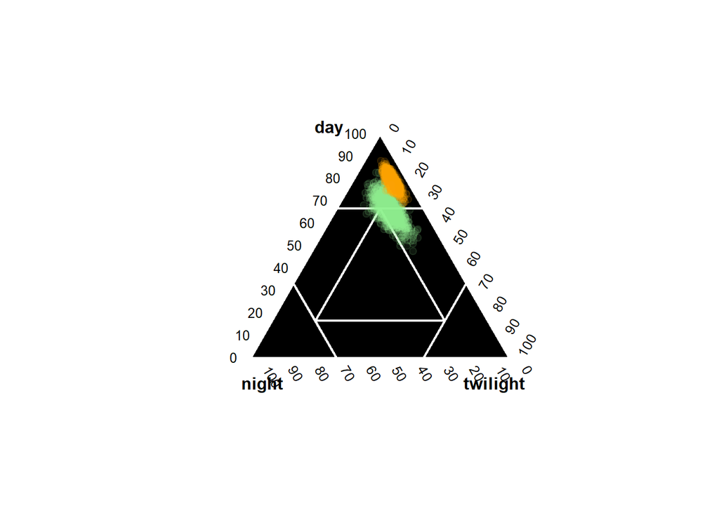

```r
idx <- which(unique(species.info3$SpeciesName) == sp)

n <- 1000#---subsample posterior sample for faster plotting

# Initialize the plot
TernaryPlot(
  atip = type.list.diel[1],
  btip = type.list.diel[2],
  ctip = type.list.diel[3],
  grid.col = NA,
  grid.minor.col = NA
)

plotTernaryRegions(
  n.categories = 7,
  col = "black",
  lwd = 2,
  border = "white"
)

coordinates.moonlit <-
  postd.moonlit[sample(dim(postd.moonlit)[1], min(n, dim(postd.moonlit)[1])), idx, ]
coordinates.moonless <-
  postd.moonless[sample(dim(postd.moonless)[1], min(n, dim(postd.moonless)[1])), idx, ]


TernaryPoints(coordinates.moonlit,
              col = adjustcolor("lightgreen", 0.1),
              pch = 19)
TernaryPoints(coordinates.moonless,
              col = adjustcolor("orange", 0.1),
              pch = 19)
```

In addition, we can plot the distribution of the posterior signifying the change in overall activity level (expressed in photographic detections) during periods with full moon.

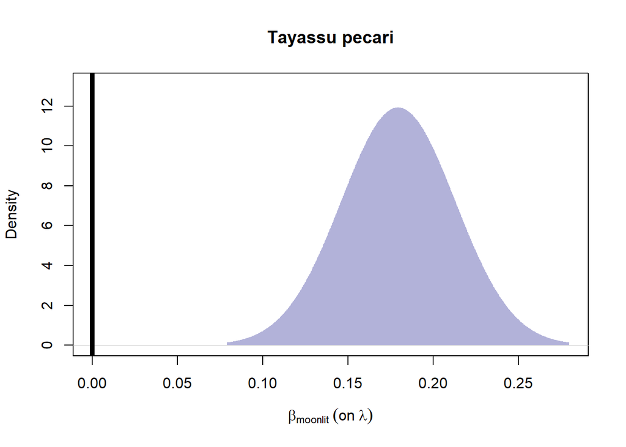

```r
#-----SHIFT POSTERIOR (TOTAL ACTIVITY)

temp<-apply(log(NimbleOutputCoda3$sims.list$lambda.dot),c(1,2),function(x)x[1]-x[2])


dimnames(temp) <- list(NULL, unique(species.info3$SpeciesName))
postd.df <- melt(temp) %>% tibble()
colnames(postd.df) <- c("iteration", "SpeciesName", "dN")
postd.df2 <-
  postd.df %>% group_by(SpeciesName)  %>% summarise(
    mean = mean(dN),
    lci = quantile(dN, 0.025),
    uci = quantile(dN, 0.975)
  )
ordered.species.list <-
  as.character(unique(postd.df2$SpeciesName[order(postd.df2$mean)]))
postd.df$SpeciesName <-
  factor(postd.df$SpeciesName, levels = ordered.species.list)
postd.df2$significant <-
  ifelse(postd.df2$lci > 0,
         "positive",
         ifelse(postd.df2$uci < 0, "negative", "not significant"))
postd.df_dN <- left_join(postd.df, postd.df2)


temp <-
  postd.df_dN$mean[postd.df_dN$SpeciesName %in% sp]

this.dens <-
  density(postd.df_dN$mean[postd.df_dN$SpeciesName %in%
                                               sp])
dens.df <- tibble(x = this.dens$x, y = this.dens$y)
dens.pos.df <- dens.df[dens.df$x > 0, ]
dens.neg.df <- dens.df[dens.df$x < 0, ]

poly.pos <- cbind(xx = c(dens.pos.df$x, rev(dens.pos.df$x))
                  ,
                  yy = c(dens.pos.df$y, rep(0, length(dens.pos.df$y))))

poly.neg <- cbind(xx = c(dens.neg.df$x, rev(dens.neg.df$x))
                  ,
                  yy = c(dens.neg.df$y, rep(0, length(dens.neg.df$y))))

ylim = c(0, max(this.dens$y) * 1.1)
xlim <- c(min(c(0, this.dens$x)), max(c(this.dens$x, 0)))
xlab <- expression(beta[moonlit] ~ (on ~ lambda))
plot(
  this.dens,
  lwd = 2,
  type = "n",
  xlab = xlab,
  ylab = "Density",
  xlim = xlim,
  ylim = ylim,
  main = sp
)
polygon(poly.pos, col = adjustcolor("navy", 0.3), border = NA)
polygon(poly.neg, col = adjustcolor("red", 0.3), border = NA)

abline(v = 0, col = "black", lwd = 5)
```

This figure suggests that the white-lipped peccary increases its overall activity during periods with moonlit nights.

## References

de Valpine, Perry, Daniel Turek, Christopher J Paciorek, Clifford Anderson-Bergman, Duncan Temple Lang, and Rastislav Bodik. 2017. “Programming with Models: Writing Statistical Algorithms for General Model Structures with NIMBLE.” *J. Comput. Graph. Stat.* 26 (2): 403–13.

Gelman, A. 1996. “Inference and monitoring convergence.” In *Markov Chain Monte Carlo in Practice*, edited by W R Gilks, S Richardson, and D J Spiegelhalter, 131–43. London, UK: Chapman; Hall.

NIMBLE Development Team. 2020. “NIMBLE: MCMC, Particle Filtering, and Programmable Hierarchical Modeling.” https://doi.org/10.5281/zenodo.1211190.

R Core Team. 2023. *R: A Language and Environment for Statistical Computing*. Vienna, Austria: R Foundation for Statistical Computing. https://www.R-project.org/.

Smith, Martin R. 2017. “Ternary: An r Package for Creating Ternary Plots.” *Comprehensive R Archive Network*. https://doi.org/10.5281/zenodo.1068996.